# Lab 5: Simulation

# The Central Limit Theorem

Recall that the **Central Limit Theorem** tells us about the distribution of a sample mean, which is called the sampling distribution. As sample size becomes large, the sampling distribution approaches a normal distribution, and the standard deviation of the sampling distribution decreases.

Let’s take a look at what exactly all this means.

**For this assignment, use a seed of 369.**

## Part One: The CLT

1. Suppose we have a quantity that we know is Normally distributed with mean 50 and standard deviation 10. Below, I have generated 1000 samples from this variable, and plotted the density.

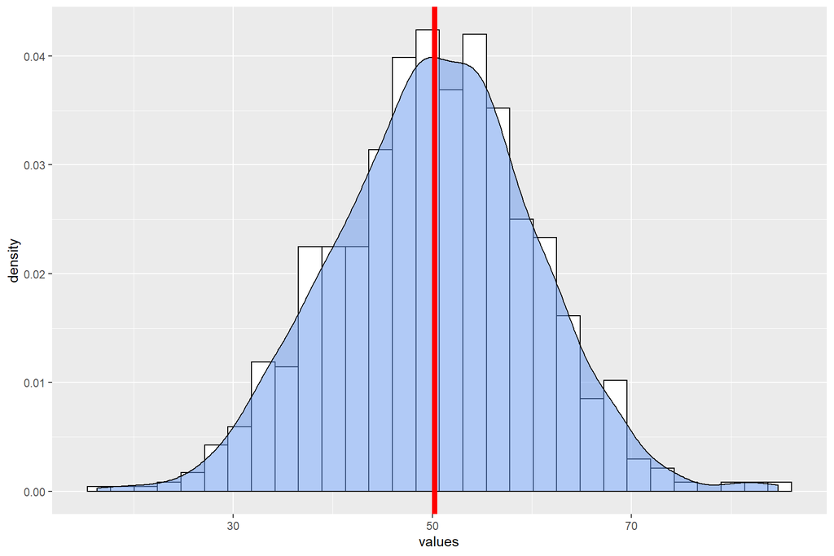

```r
my_samples <- data.frame(
  values = rnorm(1000, mean = 50, sd = 10)
)

ggplot(my_samples, aes(x = values)) +
  geom_histogram(aes(y = ..density..),
                 fill = "white",
                 color = "black") +
  geom_density(fill = "cornflowerblue", alpha = 0.5) +
  geom_vline(xintercept = mean(my_samples$values), color = "red", lwd = 2)
```

- What were the mean and standard deviation of the samples?

```r
my_samples %>%
  summarize(mean(values), sd(values))
```

```
##   mean(values) sd(values)
## 1     50.20819   9.975064
```

- Simulate a sample of size 30 from this population, and find the mean and standard deviation. How do they compare to your answers above?

```r
my_samples <- data.frame(
  values = rnorm(30, mean = 50, sd = 10)
)

my_samples %>%
  summarize(mean(values), sd(values))
```

```
##   mean(values) sd(values)
## 1     51.96935   9.354398
```

```
The mean and sd should be close to the same for both answers.
```

```
The following is NOT correct:
```

```r
sample(my_samples$values, 30)
```

```
##  [1] 41.03989 47.65800 37.10617 51.05824 54.45928 51.26760 68.33840 60.58884
##  [9] 47.75237 63.27350 53.95278 57.10051 69.17563 58.22975 50.60927 57.66925
## [17] 47.48385 64.65095 55.65554 40.76308 35.81352 50.69222 49.26645 49.25539
## [25] 68.08185 42.37981 43.03471 58.95816 42.96862 40.79697
```

2. Repeat Question 1, this time for a variable that has an `exponential(0.02)` distribution.

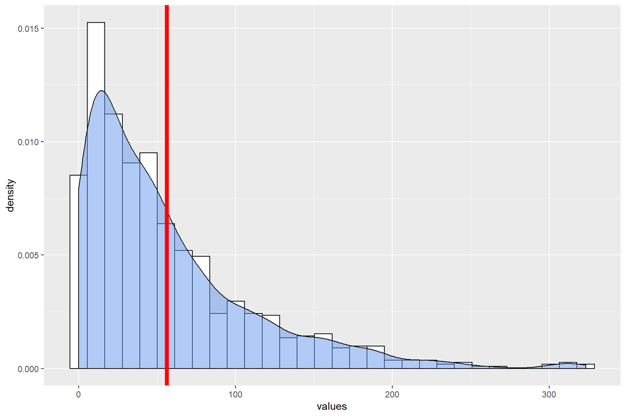

```r
my_samples <- data.frame(
  values = rexp(1000, rate = 0.02)
)

ggplot(my_samples, aes(x = values)) +
  geom_histogram(aes(y = ..density..),
                 fill = "white",
                 color = "black") +
  geom_density(fill = "cornflowerblue", alpha = 0.5) +
  geom_vline(xintercept = mean(my_samples$values), color = "red", lwd = 2)
```

```r
my_samples %>%
  summarize(mean(values), sd(values))
```

```
##   mean(values) sd(values)
## 1     56.00253   55.03214
```

```r
my_samples_30 <- data.frame(
  values = rexp(30, rate = 0.02)
)

my_samples_30 %>%
  summarize(mean(values), sd(values))
```

```
##   mean(values) sd(values)
## 1     44.51474   47.07226
```

```
The mean and sd should be close to the same for both answers.
```

3. Still using the `exponential(0.02)`, simulate 1000 samples of size 30, and calculate the sample mean of each one. Make a density plot of these *sample means*.

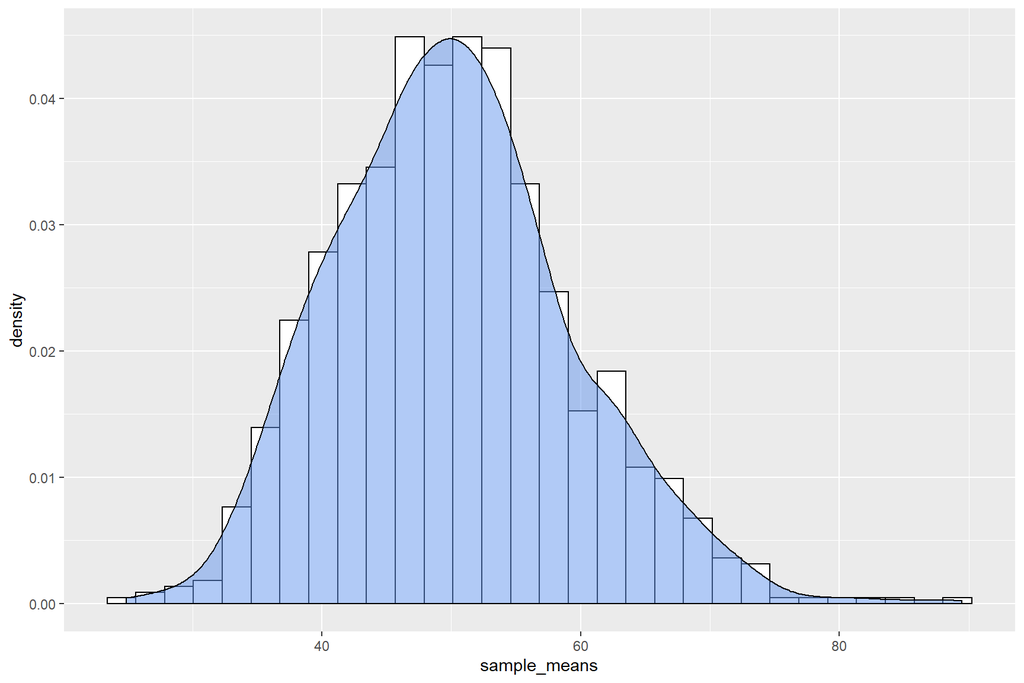

```r
many_samples <- replicate(1000, rexp(30, rate = 0.02), simplify = FALSE)

my_sample_stats <- data.frame(
  sample_means = map_dbl(many_samples, mean)
)

my_sample_stats %>%
  ggplot(aes(x = sample_means)) +
  geom_histogram(aes(y = ..density..),
                 fill = "white",
                 color = "black") +
  geom_density(fill = "cornflowerblue", alpha = 0.5)
```

4. Comment on your plot from (3). How was the distribution of the sample means different from the distribution of the original variable?

```
Roughly normally distributed, not as skewed.
```

5. Find the standard deviation of your 1000 sample means. How does it compare to the standard deviation of your single sample from 2(b)? *Hint: Divide the sd of the single sample by the sd of the sample means. Then square that.*

```r
sd(my_samples$values)
```

```
## [1] 55.03214
```

```r
sd(my_sample_stats$sample_means)
```

```
## [1] 9.149503
```

```r
## (exact values will vary)

(50/9.13)^2
```

```
## [1] 29.99152
```

```
The variance of the sample means is the variance of the single samples divided by n.
```

## Part Two: Beyond the Mean

The Central Limit Theorem works “like magic” when dealing with sample means. But what about other statistics?

Continue to study the `exponential(0.02)` distribution.

1. The Median
- What is the true median of this distribution?

```r
qexp(.5, 0.02)
```

```
## [1] 34.65736
```

```
NOT CORRECT:
```

```r
median(my_samples$values)
```

```
## [1] 39.98665
```

- Return to your 1000 samples of size 30. Find the median of each sample. Make a plot of the density of all the medians, with a vertical line representing the true median.

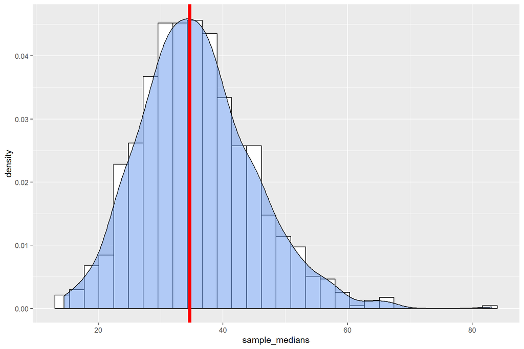

```r
my_sample_stats <- my_sample_stats %>%
  mutate(
    sample_medians = map_dbl(many_samples, median)
  )

my_sample_stats %>%
  ggplot(aes(x = sample_medians)) +
  geom_histogram(aes(y = ..density..),
                 fill = "white",
                 color = "black") +
  geom_density(fill = "cornflowerblue", alpha = 0.5) +
  geom_vline(xintercept = qexp(.5, 0.02), color = "red", lwd = 2)
```

- Based on your plot above, do you think the CLT applies to the median of an exponential distribution?

```
Comment on whether or not it looks Normally distributed around a center at the true value of the median.
```

2. Repeat Q1, this time for the *midhinge* of each sample. (You may have to google this!)

```r
mh <- (qexp(.75, 0.02) + qexp(.25, 0.02))/2
mh
```

```
## [1] 41.84941
```

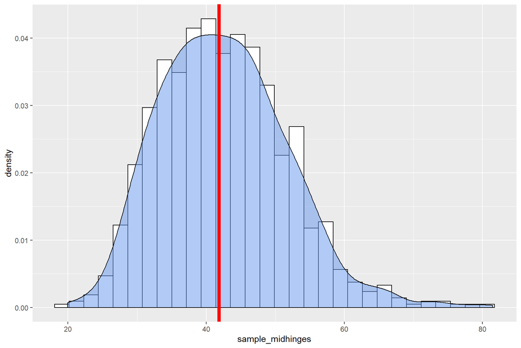

```
Comment on whether or not it looks Normally distributed around a center at the true value of the midhinge.
```

```r
midhinge <- function(sample) {

  q1 <- quantile(sample, .25)
  q3 <- quantile(sample, .75)

  return((q1+q3)/2)

}


my_sample_stats <- my_sample_stats %>%
  mutate(
    sample_midhinges = map_dbl(many_samples, midhinge)
  )

my_sample_stats %>%
  ggplot(aes(x = sample_midhinges)) +
  geom_histogram(aes(y = ..density..),
                 fill = "white",
                 color = "black") +
  geom_density(fill = "cornflowerblue", alpha = 0.5) +
  geom_vline(xintercept = mh, color = "red", lwd = 2)
```

3. Repeat Q1, this time taking the *maximum* of each sample. (There is no coding way to find the true maximum; make your best guess.)

```r
qexp(1, 0.02)
```

```
## [1] Inf
```

```
There is no maximum!
```

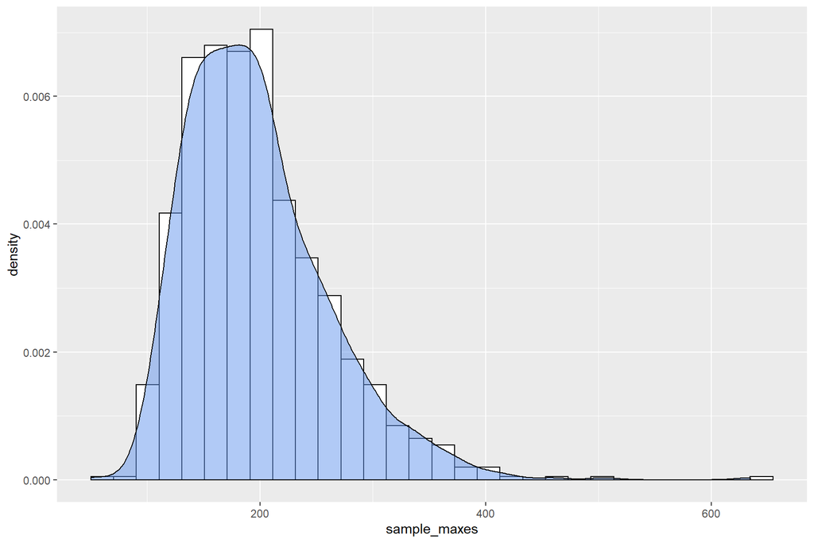

```
No!  Even if it looks a little bell-shaped, it can't possibly be centered at the true value (infinity).
```

```r
my_sample_stats <- my_sample_stats %>%
  mutate(
    sample_maxes = map_dbl(many_samples, max)
  )

my_sample_stats %>%
  ggplot(aes(x = sample_maxes)) +
  geom_histogram(aes(y = ..density..),
                 fill = "white",
                 color = "black") +
  geom_density(fill = "cornflowerblue", alpha = 0.5)
```

## Part Three: Appreciate the usefulness

You have been told that the amount of time you have to wait for a bus from Cal Poly to Downtown SLO is `exponential(0.02)`.

You think this might be a lie. In the last 30 days, you have waited for the bus an average of 55 minutes.

If the bus system is telling the truth about the `exponential(0.02)` distribution, how unlucky would you have to have been this month?

Make an argument both by direct simulation, and by using the Central Limit Theorem.

(*Hint: The mean of `exponential(0.02)` is `50`, and the sd is equal to the mean.*)

#### Using simulation:

We’ve already simulated 1000 samples of size 30 from this population!

```r
sum(my_sample_stats$sample_means > 55)/1000
```

```
## [1] 0.274
```

#### Using CLT:

The sample mean is approximately Normal, with a mean of 50 and a sd of 50/sqrt(30).

```r
pnorm(55, mean = 50, sd = 50/sqrt(30))
```

```
## [1] 0.7080588
```

## Flex Points:

Use Google or other resources to learn about the **Normal approximation to the Binomial distribution**.

Write a very brief explanation of this phenomenon, that makes use of simulation and visualization to illustrate the concept.

Upload your writeup **separately** to Canvas.

Stat 331